# Vortex & Phase Slip

### Vortex

A vortex has its topological origin as we already known. In reduced systems, vortex plays a dominated role in determining the physical behavior of the system, such as the BKT transition in two dimension situations and the phase slip events (imagined as a vortex in 1+1 dimension) in one dimension situations where fluctuation both thermal and quantum fluctuation activated coming into play.

In two dimension situations, a vortex is a zero dimension object with the order parameter going to zero at a single point at its center. Because of the presence of vortices, the phase of the order parameter is multivalued and can not be well defined at the vertex centers(when the magnitude of order parameter is take down to zero, one gets a infinite choices of its phase). We can get some insights from the complex analysis where a vortex can be viewed as a singularity. On the other hand, the phase gradient $\mathbf { v}=\nabla \phi$ is single-valued(still undefined at the center). Recall the natural boundary condition constraint taking its path integral form in the situation as,

$$ \oint d \mathbf { s } \cdot \mathbf { v } = \int d ^ { 2 } x \hat { z } \cdot ( \nabla \times \mathbf { v} ) =\text { total change in phase along } \mathcal { C } = 2 \pi N _ { \mathcal { C } } $$

where $ N _ { \mathcal { C } } \in \mathbb { Z } $ is the enclosed winding number (vorticity or topological charge). Hence we can the identity underlying significant physical meaning. $$ \nabla \times \mathbf { u } = 2 \pi \hat { z } \sum _ { j } n _ { j } \delta ^ { 2 } \left( \mathbf { r } - \mathbf { r } _ { j } \right) $$

Let's go further to examine the property of $\mathbf{v}$. It's always possible to decomposes a vector filed into a rotation-free and a divergence-free component.

$$ \begin{array} { c } { \mathbf { v } = \mathbf { v } _ { \mathrm { ph } } + \mathbf { v } _ { v } } \\ { \nabla \times \mathbf { v } _ { \mathrm { ph } } = 0 } \\ { \nabla \cdot \mathbf { v } _ { v } = 0 } \end{array} $$

As can be seen, the votex concentration associated with vanishes and one can always find a single-valued scalar field $\Omega$ , such that $\mathbf { v } _ { \mathrm { ph } } = \nabla \Omega$, which has nothing to do with vortices but can get its origin from small phase fluctuations.

As for the vortex part,

$$ \begin{array} { c } { \nabla \times \mathbf { v } _ { v } = 2 \pi n _ { v } } \\ { \nabla \cdot \mathbf { v } _ { v } = 0 } \end{array} $$

it seems like a electric field in Maxwell Equations but shows uncompatible contradictions under a prudent inspection. However , things go to clear when we consider a similar Hodge dual transformation (clifford algebra) in electromagnetic field (E-1form, B-2form) by introducing a pseudo-electric field(2 form).

$$ \mathbf { E } ( \mathbf { r } ) : = - \underbrace { \sqrt { - 2 \gamma \frac { \alpha } { \beta } } } _ { > 0 } \hat { \mathbf { z } } \times \mathbf { v } _ { v } ( \mathbf { r } ) $$$$ \begin{array} { c } { - \gamma \frac { \alpha } { \beta } \left( \nabla \phi _ { v } \right) \cdot \nabla \phi _ { v } = - \gamma \frac { \alpha } { \beta } \mathbf { v } _ { v } \cdot \mathbf { v } _ { v } = - \gamma \frac { \alpha } { \beta } \left( - 2 \gamma \frac { \alpha } { \beta } \right) ^ { - 1 } \mathbf { E } \cdot \mathbf { E } = \frac { 1 } { 2 } \mathbf { E } \cdot \mathbf { E } } \\ { \nabla \cdot \mathbf { E } = - \sqrt { - 2 \gamma \frac { \alpha } { \beta } } \left( - \nabla \times \mathbf { v } _ { v } \right) = 2 \pi \sqrt { - 2 \gamma \frac { \alpha } { \beta } } n _ { v } } \\ { \nabla \times \mathbf { E } = 0 } \end{array} $$$$ \begin{aligned} \oint d \mathbf { a } \cdot \mathbf { E } & = 2 \pi r E = 2 \pi \sqrt { - 2 \gamma \frac { \alpha } { \beta } } \\ \Rightarrow \quad E ( \mathbf { r } ) & = \frac { \sqrt { - 2 \gamma \frac { \alpha } { \beta } } } { r } \\ \mathbf { E } ( \mathbf { r } ) & = \frac { \sqrt { - 2 \gamma \frac { \alpha } { \beta } } } { r } \hat { \mathbf { r } } \end{aligned} $$

The vortices in a two-dimensional superfluid behave like a Coulomb gas—a gas of charged particles with Coulomb interaction, which is logarithmic in 2D.

The following is the references from which I benefit a lot.

https://drum.lib.umd.edu/bitstream/handle/1903/22074/Liu_umd_0117E_19501.pdf?sequence=2&isAllowed=y

Theory of Superconductivity Carsten Timm

https://www.physik.tu-dresden.de/~timm/personal/teaching/thsup_w11/Theory_of_Superconductivity.pdf

Introduction to the Berezinskii-Kosterlitz-Thouless Transition

http://guava.physics.uiuc.edu/~nigel/courses/563/Essays_2013/PDF/Packard.pdf

Dissipative Phase Transitions http://guava.physics.uiuc.edu/~nigel/courses/563/Essays_2008/PDF/gopalakrishnan.pdf

Thermally activated phase slips and quantum phase slips in one-dimensional superconductors

http://guava.physics.uiuc.edu/~nigel/courses/569/essays_f2004/files/sahu.pdf

Stabilizing Superconductivity in Nanowires by Coupling to Dissipative Environments https://journals.aps.org/prl/abstract/10.1103/PhysRevLett.96.157005

[Schrieffer,_John_Robert]_Theory_of_superconductivity

The following contents is exactly a copy of references.

## Phase Slip

#### Mermin-Wager theorem

According to Mermin-Wagner theorem superconducting long-range order is impossible in strictly one or two dimensional systems at any finite temperature. Below TC fluctuations should destroy the long-range order in low dimensional superconductors. We may wondering what's going on for the superconductivity in the reduced dimensions as strong phase fluctuation effects enters.

The world we are entering to is far more fascinating and unexpected beyond imagination. For instance, 2D structures undergo a Berezinskii–Kosterlitz–Thouless (BKT) phase transition ,as a result of which the decay of correlations in space changes from exponential at high enough T to power law at low temperatures. This result implies that at low T long range phase coherence essentially survives in samples of a finite size and, hence, 2D films can well exhibit superconducting properties. Can superconductivity survive also in (quasi)-1D systems or do fluctuations suppress phase coherence thus disrupting any supercurrent?

It was first pointed out by Little that quasi-one-dimensional wires made of a superconducting material can acquire a finite resistance below TC of a bulk material due to the mechanism of thermally activated phase slips (TAPS). Within the Ginzburg–Landau theory one can describe a superconducting wire by means of a complex order parameter Ψ(x) = |Ψ(x)|eiϕ(x). Thermal fluctuations cause deviations of both the modulus and the phase of this order parameter from their equilibrium values. A non-trivial fluctuation corresponds to temporal suppression of |Ψ(x)| down to zero at some point.(e.g., x = 0) inside the wire, see Fig. 1. As soon as the modulus of the order parameter |Ψ(0)| vanishes the phase ϕ(0) becomes unrestricted and can jump by the value 2πn, where n is any integer number. After this process the modulus |Ψ(0)| gets restored, the phase becomes single valued again and the system returns to its initial state accumulating the net phase shift 2πn. Provided such phase slip events are sufficiently rare, one can restrict nbyn = ±1and totally disregard fluctuations with |n| ≥ 2.

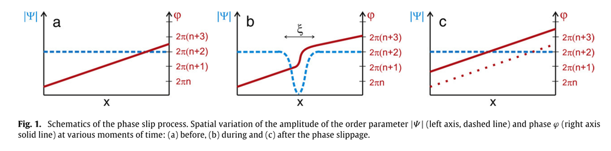

According to the Josephson relation V = ¯h ˙ϕ/2e each such phase slip event causes a nonzero voltage drop V across the wire. In the absence of any bias current the net average numbers of ‘‘positive’’ (n = +1) and ‘‘negative’’ (n = −1) phase slips are equal, thus the net voltage drop remains zero. Applying the current I ∝| Ψ |2 ∇ϕ one creates a nonzero phase gradient along the wire and makes ‘‘positive’’ phase slips more likely than ‘‘negative’’ ones. Hence, the net voltage drop V due to TAPS differs from zero, i.e. thermal fluctuations cause non-zero resistance R = V/I of superconducting wires even below TC.

During a phase slip, the superconducting order parameter fluctuates to zero at some point along the wire, allowing the relative phase across the point to slip by 2π, resulting in a voltage pulse; the sum of these pulses gives the resistive voltage.

A quantitative theory of the TAPS phenomenon was first proposed by Langer and Ambegaokar and then completed by McCumber and Halperin . This LAMH theory predicts that the TAPS creation rate and, hence, resistance of a superconducting wire R below TC are determined by the activation exponent.

#### Thermally activated phase slips:

Theoretical study of the processes, which can suppress superconductivity in 1D wires dates back to the 1960s, when Langer, Ambegaokar, McCumber and Halperin (LAMH)(1967, 1970) developed the theory of thermally-activated phase slips, which explained resistances and dissipation in thin wires below TC.

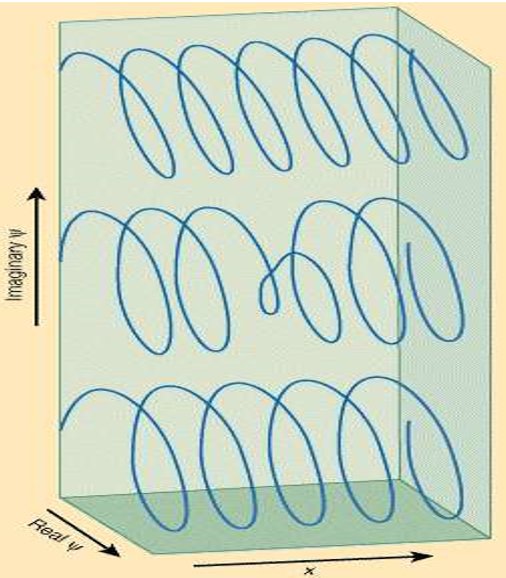

#### LAMH Theory:

Next, we must build in the effect of the current through the wire in making jumps more probable in one direction than in the other. In the absence of a current, phase slips by $±2\pi$ are equally likely; this gives a fluctuating noise voltage but no dc component. Given a driving voltage V, however, the current will build up to a steady-state value at which the $\Delta \varphi _ { 12 } = - 2 \pi$ jumps outnumber the $ \Delta \varphi _ { 12 } =+2 \pi $ jumps by an amount 2eV/h per second. The different jump rates rise from a difference $\delta F$ in the energy barrier for jumps in the two directions, and this difference stems from the electrical work IV'dt done in the process, as in the tilted-washboard model In view of Josephson Equation , for a phase slip of $±2\pi$, the energy difference is

$$ \frac { d \varphi _ { 12 } } { d t } = \frac { 2 e V } { \hbar } $$$$ \delta F = \Delta F _ { + } - \Delta F _ { - } = \frac { h } { 2 e } I $$

The LAMH theory applies to narrow superconducting channels in which thermal fuctuations can cause phase slips, i.e. jumps in the phase difference of the order parameter by 2π. Thermal activations of the system over a free energy barrier ∆F occur at a rate given by Ω(T)e-∆F/kT where a attempt frequency Ω(T) is introduced. So the mean net phase-slip rate takes the following form.

$$ \begin{aligned} \frac { d \varphi _ { 12 } } { d t } & = \Omega \left[ \exp \left( - \frac { \Delta F _ { 0 } - \delta F / 2 } { k T } \right) - \exp \left( - \frac { \Delta F _ { 0 } + \delta F / 2 } { k T } \right) \right] \\ & = 2 \Omega e ^ { - \Delta F _ { 0 } / k T } \sinh \frac { \delta F } { 2 k T } \end{aligned} $$$$ \Omega = \frac { L } { \xi } \left( \frac { \Delta F _ { 0 } } { k T } \right) ^ { 1 / 2 } \frac { 1 } { \tau _ { s } } $$

is inversely proportional to the relaxation time of the time –dependent Ginzburg-Landau (GL) theory τGL = 8k(Tc -T)/πh (L is the wire length, ξ(T) is the GL coherence length, and Tc is the mean field critical temperature of the wire). Combine the equation and the previous Josephson equation, we find

$$ V = \frac { \hbar \Omega } { e } e ^ { - \Delta F _ { 0 } / k T } \sinh \frac { h I } { 4 e k T }=\frac { \hbar \Omega } { e } e ^ { - \Delta F _ { 0 } / k T } \sinh \frac { I } { I_0 } $$

In the limit of very samll currents, the hyperbolic sine can be replaced by its argument, and one obtains Ohm's law. $$ R_{LAMH}= \frac { V } { I } = \frac { \pi \hbar ^ { 2 } \Omega } { 2 e ^ { 2 } k T } e ^ { - \Delta F _ { 0 } / k T } = R_q \frac { \hbar \Omega } { k T } e ^ { - \Delta F _ { 0 } / k T } $$ where $ \mathrm { R } _ { \mathrm { q } } = \mathrm { h } / ( 2 \mathrm { e } ) ^ { 2 } $ . However, this approximation is valid only for I<= I0, where

$$ I _ { 0 } = \frac { 4 e k T } { h } = 0.013 \mu \mathrm { A } / \mathrm { K } $$

#### Macroscopic Quantum Phase Slips:

Following the standard quantum mechanical arguments one can expect that the probability of such a tunneling process should be controlled by the exponent∼exp(−∆F/¯hω0), i.e. instead of temperature in the activation exponent one should just substitute ¯hω0, where ω0 is an effective attempt frequency. This is because the order parameter field Ψ(x) now tunnels under the barrier U rather than overcomes it by thermal activation. Since such a tunneling process should obviously persist down to T = 0 one arrives at a fundamentally important conclusion that in nanowires superconductivity can be destroyed by quantum fluctuations at any temperature including T = 0. Accordingly, such nanowires should demonstrate a non-vanishing resistivity down to zero temperature. Assuming that ¯hω0∼ ∆0(T) one would expect that at $ \Delta _ { 0 } ( T ) \lesssim T < T _ { C } $ the TAPS dependence applies while at lower T < ∆0(T) quantum phase slips (QPS) take over, eventually leading to saturation of the temperature dependence R(T) to a non-zero value in the limit T << ∆0.

Such mechanism for phase slippage is known as macroscopic quantum tunneling (MQT) because it involves the collective motion of the electron condensate in a volume ~A which typically contains 10^8 or more electrons.

##### Giordano’s Model:

The physical idea underlying Giordano’s treatment of MQT of phase slips is quite simple. He considers the motion of a damped particle moving in a tilted washboard potential, and assumes that the particle can be treated as a simple harmonic oscillator in a well, with a small oscillation frequency ω0.

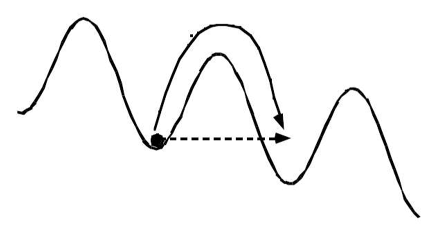

Figure2. Tilted washboard potential. A particle trapped in one of the minima can reach the lower energy state by either thermal activation (solid line) or quantum tunneling (dashed line).

Then the tunneling rate can be written in the form (Caldeira and Leggett, 1981) $$ \Gamma _ { M Q T } = B \sqrt { \frac { V _ { o } \omega _ { o } } { \mathrm { h } } } e ^ { - a V _ { o } / \mathrm { h } \omega _ { o } } $$

where V0 is the barrier height, and B and a are constants. Giordano argues that V0 should be identified with ΔF the free energy barrier in the LAMH theory: and since $\tau_GL$ is the only time scale in the time dependent GL theory, it is natural to identify ω0 with $\tau_GL$. Therefore,

$$ \Gamma _ { M Q T } = B \sqrt { \frac { \Delta F } { \mathrm { h } \tau _ { G L } } } e ^ { - a \Delta F \tau _ { G L } / \mathrm { h } } $$

Following the standard procedure used to obtain resistance from phase slip rate and inserting the factor L/ξ(which is the number of difference places along the wire that phase slips can occur), one obtains,

$$ R _ { M Q T } = B \frac { L } { \xi } R _ { q } \sqrt { \frac { \Delta F } { \mathrm { h } \tau _ { G L } } } e ^ { - a \Delta F \tau _ { G L } / \mathrm { h } } $$

one can easily see that apart from numerical constants, RMQT can be obtained from the LAMH form by simply replacing the energy scale kT by h/ ξGL , which is also physically reasonable.